[figure not shown]

Platinum Priority – Review – Reconstructive Urology

Editorial by Karl-Dietrich Sievert on pp. 607–609 of this issue

Tissue Engineering of the Urethra: A Systematic Review and

Meta-analysis of Preclinical and Clinical Studies

Luuk R.M. Versteegden <sup>a</sup><sup>,</sup><sup>y</sup>, Paul K.J.D. de Jonge <sup>b</sup><sup>,</sup><sup>y</sup>, Joanna IntHout <sup>c</sup>, Toin H. van Kuppevelt <sup>a</sup>,

Egbert Oosterwijk <sup>b</sup>, Wout F.J. Feitz <sup>b</sup><sup>,</sup><sup>d</sup>, Rob B.M. de Vries <sup>e</sup>, Willeke F. Daamen <sup>a</sup><sup>,</sup>*

a Department of Biochemistry, Radboud Institute for Molecular Life Sciences, Radboud university medical center, Nijmegen, The Netherlands; b Department of

Urology, Radboud Institute for Molecular Life Sciences, Radboud university medical center, Nijmegen, The Netherlands; <sup>c</sup>Department for Health Evidence,

Radboud Institute for Health Sciences, Radboud university medical center, Nijmegen, The Netherlands; <sup>d</sup>Radboudumc Amalia Children’s Hospital, Radboud

university medical center, Nijmegen, The Netherlands; <sup>e</sup>SYRCLE (SYstematic Review Centre for Laboratory Animal Experimentation), Department for Health

Evidence (section HTA), Radboud Institute for Health Sciences, Radboud university medical center, Nijmegen, The Netherlands

available at www.sciencedirect.com

journal homepage: www.europeanurology.com

[figure not shown]

Article info

Article history:

Accepted March 17, 2017

Associate Editor:

Christian Gratzke

Keywords:

Urethra

Reconstructive surgery

Tissue engineering

Systematic review

Meta-analysis

Clinical studies

Preclinical studies

[figure not shown]

europeanurology to read and

answer questions on-line.

The EU-ACME credits will

then be attributed

automatically.

Abstract

Context: Urethra repair by tissue engineering has been extensively studied in laboratory

animals and patients, but is not routinely used in clinical practice.

Objective: To systematically investigate preclinical and clinical evidence of the efﬁcacy

of tissue engineering for urethra repair in order to stimulate translation of preclinical

studies to the clinic.

Evidence acquisition: A systematic search strategy was applied in PubMed and EMBASE.

Studies were independently screened for relevance by two reviewers, resulting in

80 preclinical and 23 clinical studies of which 63 and 13 were selected for meta-analysis

to assess side effects, functionality, and study completion. Analyses for preclinical and

clinical studies were performed separately. Full circumferential and inlay procedures

were assessed independently. Evaluated parameters included seeding of cells and type

of biomaterial.

Evidence synthesis: Meta-analysis revealed that cell seeding signiﬁcantly reduced the

in preclinical studies other biomaterials showed promising outcomes as well. No direct

comparison to current clinical practice could be made due to the limited number of

randomized controlled studies.

Conclusions: Due to a lack of controlled (pre)clinical studies, the efﬁcacy of tissue

engineering for urethra repair could not be determined. Meta-analysis outcome mea-

sures were similar to current treatment options described in literature. Surprisingly, it

appeared that favorable preclinical results, that is inclusion of cells, were not translated

to the clinic. Improved (pre)clinical study designs may enhance clinical translation.

Patient summary: We reviewed all available literature on urethral tissue engineering to

assess the efﬁcacy in preclinical and clinical studies. We show that improvements to

(pre)clinical study design is required to improve clinical translation of tissue engineering

technologies.

# 2017 European Association of Urology. Published by Elsevier B.V. All rights reserved.

y These authors contributed equally to the study results.

* Corresponding author. Post Ofﬁce Box 9101, 6500 HB Nijmegen, The Netherlands.

Tel. +31 24 36 10557; Fax: +31 24 35 40339.

E-mail address: Willeke.Daamen@radboudumc.nl (W.F. Daamen).

http://dx.doi.org/10.1016/j.eururo.2017.03.026

0302-2838/# 2017 European Association of Urology. Published by Elsevier B.V. All rights reserved.

1.

Introduction

Congenital birth defects of the urethra, such as hypospadias

(1 in every 300 births) [1,2], and acquired urethral

abnormalities, such as urethral strictures (1 in every

1000 men > 65 yr of age [3]), represent major clinical

entities. Treatment usually involves a surgical procedure

with risk of (recurrence of) strictures or fistula requiring

additional care or reintervention. Whenever possible, local

tissue flaps or stricture resection in combination with end-

to-end anastomosis are used for urethra reconstruction

[4,5]. Generally, two surgical approaches exist for urethral

reconstruction: partial replacements using onlay or inlay

techniques or the full circumferential procedure, which is

used in rare cases with significant urethral scarring or lichen

sclerosis. Depending on patient and local factors, proce-

dures can be performed as one-stage procedure or as

planned multistage procedure [3].

Autologous tissue transplantation such as buccal mucosa

or free skin grafts are the standard treatments [6–9].

However, due to the limited quantity of available donor

tissue, accompanying donor site morbidity (16–32% for

buccal mucosa grafts) and complications (eg, recurrences or

infections), alternative treatment options are needed to

improve long-term outcomes [10]. Tissue engineering may

overcome some of the aforementioned disadvantages by

providing a temporary template to guide tissue regenera-

tion [11]. In general, tissue engineered templates include

decellularized tissue or de-novo prepared materials from

natural or synthetic origin [12–14]. Templates can be

seeded

with

(stem)

cells

from

the

patient

prior

to

implantation. These cells may stimulate tissue remodeling

by excreting cytokines and growth factors and contributing

to cellular population of the template [15,16].

Despite the potential of tissue engineering shown in in

vitro research and preclinical studies, clinical translation is

limited. To improve translation, an evidence-based ap-

proach, such as systematic reviews, can be applied when

designing new tissue engineering strategies. This will avoid

unnecessary replication of studies and will help to select the

most optimal experimental design and model. We are the

first to perform a comprehensive systematic review of

evidence for the efficacy of urethral tissue engineering in

preclinical and clinical studies. A meta-analysis was used to

compare different experimental designs based on clinically

relevant outcomes. This systematic review aims to improve

the translation of urethral tissue engineering from bench to

bedside.

2.

Evidence acquisition

2.1.

Literature search

To identify all available studies on urethral tissue engineer-

ing published and indexed up until June 1, 2016, a systematic

search strategy was applied in PubMed (Supplementary data

1) and Embase (via OvidSP; Supplementary data 2). This

strategy combined a tissue engineering search component

containing synonyms for tissue engineering related terms

[17] with a customized search component for urethra or

urethra-related diseases. Medical Subject Headings terms

and EMTREE terms were used in PubMed and Embase,

respectively, together with separate words or word combi-

nations in title or abstract. Next, either an animal filter

designed by Hooijmans et al (PubMed) [18] or de Vries et al

(Embase) [19] was applied (Supplementary data 1 and 2,

search component 3A) or a custom filter for clinical studies

(Supplementary data 1 and 2, search component 3B). In

addition, retrieved reviews were screened for primary

studies not found using the search strategy. Clinical studies

found during animal search strategy were marked and

screened for relevance and vice versa.

2.2.

Study selection

Duplicates in retrieved articles were removed in EndNote

(Version X7.2, Thomson Reuters, PA, USA). Studies were

assessed independently by LV and PdJ. First, clearly

irrelevant studies were excluded based on title. Next, titles

and abstracts of the remaining articles were screened for

relevance in Early Review Organizing Software (Buenos

Aires, Argentina, www.eros-systematic-review.org) using

the following exclusion criteria: (1) no urethra, (2) no tissue

engineering, (3) no animals or patient, (4) no primary study.

A study was considered to be about tissue engineering when

a processed template was used. Studies on tissue trans-

plants or reconstructive surgery without the use of a

template or without a urethra defect were excluded. Of

the remaining studies, full texts were screened using the

same exclusion criteria. Articles not available as full text

were excluded at this stage. No language restrictions were

applied in the screening phase. If necessary, Google

translate was used. Retrieved studies from search updates

were directly screened in Endnote according to the same

principles. In all stages of the selection process, discrepan-

cies between reviewers were discussed until consensus was

reached.

2.3.

Study characteristics

From all included studies, general information (author,

year) and study characteristics (age range of patients,

animal species, sex, surgical procedure, type of biomaterial,

type of cells) were extracted and listed in Table 1 for

preclinical studies and Table 2 for clinical studies. For

languages other than English, German, and French, Google

Translate was used to retrieve study characteristics.

2.4.

Extraction outcome data

Three outcome measures were used to evaluate study

outcome:

(1)

incidence

of

side

effects,

for

example,

strictures, stenosis, fistulae, and infections, (2) functionality,

defined as the ability to void with continence, and (3)

study completion, for animals defined as survival until

predetermined

endpoint

and

for

clinical

studies

as

available for follow-up or no additional urethroplasty

required. Only English, German, and French studies were

[figure not shown]

Table 1 – Study characteristics of all 80 preclinical studies sorted on inclusion in meta-analysis, surgical procedure, and biomaterial

Author

Yr

Animal

model

No. of

animals

Sex

Surgical

procedure

(defect length

in mm)

Biomaterial

(category)

Type of added cells

Quality

assessment +

meta-analysis

1

Feng C

2011

Rabbit

28

M

Inlay (15)

Acellular corpus

spongiosum,

porcine (D)

Autologous corporal SMCs

and lingual keratinocytes

Yes

2

Ayyildiz A

2006

Rabbit

10

M

Inlay (5)

Alloderm + acellular

pericardium,

bovine (D)

—

Yes

3

Chen F

1999

Rabbit

10

M

Inlay (10)

BAM, porcine (D)

—

Yes

4

Chun SY

2015

Rabbit

10

M

Inlay (20)

BAM, porcine (D)

Autologous minced urethral

muscle and urothelial tissue

Yes

5

Sayeg K

2013

Rabbit

18

M

Inlay (35)

BAM, porcine (D)

Autologous bladder SMCs

Yes

6

Huang JW

2014

Rabbit

30

M

Inlay (15)

BAM, rabbit (D)

—

Yes

7

Li C

2008

Rabbit

24

M

Inlay (20)

BAM, rabbit (D)

Autologous oral keratinocytes

Yes

8

Li C

2013

Rabbit

27

M

Inlay (20)

BAM, rabbit (D)

Autologous oral keratinocytes

and TGF-b siRNA transfected

ﬁbroblasts

Yes

9

Li H

2014

Rabbit

36

M

Inlay (20)

BAM, rabbit (D)

Epithelial-differentiated rabbit

adipose-derived stem cells

Yes

10

Wang F

2014

Rabbit

12

M

Inlay (10)

Denuded amnion,

human (D)

Rabbit urothelial cells

Yes

11

Kajbafzadeh

AM

2014

Rabbit

12

M

Inlay (5)

Preputial acellular

matrix, human (D)

—

Yes

12

Kawano PR

2012

Rabbit

24

M

Inlay (10)

SIS, 1- and 4 –layer,

porcine (D)

—

Yes

13

Guo H

2015

Rabbit

24

M

Inlay (20)

SIS, porcine (D)

Autologous keratinocytes and

TIMP siRNA transfected

ﬁbroblasts

Yes

14

Kropp BP

1998

Rabbit

8

M

Inlay (10)

SIS, porcine (D)

—

Yes

15

Rotariu P

2002

Rabbit

7

M

Inlay (25)

SIS, porcine (D)

—

Yes

16

Villoldo GM

2013

Rabbit

15

M

Inlay (10)

SIS, porcine (D)

—

Yes

17

Shokeir A

2003

Dog

21

M

Inlay (30)

UAM, dog (D)

—

Yes

18

Huang JW

2015

Rabbit

30

M

Inlay (20)

Cellulose (N)

Rabbit lingual keratinocytes

Yes

19

Xie M

2013

Dog

10

F

Inlay (50)

Silk ﬁbroin (N)

Autologous oral keratinocytes

and ﬁbroblasts

Yes

20

Xie M

2013

Dog

9

F

Inlay (30)

Silk ﬁbroin (N)

Dog urothelial cells

Yes

21

Sun D

2014

Rabbit

21

M

Inlay (5)

Subcutaneous implanted

autologous minced

muscle (N)

Human umbilical cord MSCs

Yes

22

Xu Y

2014

Rabbit

21

M + F

Inlay (5)

Subcutaneous implanted

autologous muscle

microsomes (N)

Human umbilical cord MSCs

Yes

23

Zhang K

2015

Rabbit

12

M

Inlay (20)

P(LA/CL) + type I collagen

in combination with ICG-001

(Wnt-pathway inhibitor) (S)

Rabbit bladder urothelial cells

Yes

24

Wang DJ

2015

Rabbit

24

M

Inlay (5)

Polylactid acid (S)

Rabbit AdSCs

Yes

25

Kelami A

1971

Dog

10

M

Inlay (30)

PTFE (S) + lyophilized dura,

human (D)

—

Yes

26

Chung YG

2014

Rabbit

8

M

Inlay (20)

Silk ﬁbroin (N) + SIS (D)

—

Yes

27

Lv X

2016

Rabbit

18

M

Inlay (15)

Silk-Keratin-Gelatin-Calcium

peroxide (N) + SIS, porcine (D)

—

Yes

28

Nuininga JE

2003

Rabbit

18

M

Inlay (10)

SIS, 1 - and 4 - layer,

porcine (D) + Type I

collagen (N)

—

Yes

29

Zhang Q

2008

Rabbit

12

M

Full (10)

Acellular amnion, human (D)

Homologous endothelial

progenitor cells

Yes

30

Parnigotto PP

2000

Rabbit

12

M

Full (10)

Acellular aorta, rabbit (D)

—

Yes

31

DeFilippo RE

2002

Rabbit

24

M

Full (10)

BAM (D)

Autologous bladder SMCs and

urothelial cells

Yes

32

El-Tabey N

2012

Dog

14

F

Full (30)

BAM (D)

Autologous bladder SMCs and

urothelial cells

Yes

33

Wang JH

2013

Rabbit

18

M

Full (30)

BAM with polylactid

acid –glycolic

acid with VEGF (D)

—

Yes

34

DeFilippo RE

2015

Rabbit

15

M

Full (30)

BAM, porcine (D)

Autologous bladder SMCs and

urothelial cells

Yes

35

Dorin RP

2008

Rabbit

12

M

Full (5–30)

BAM, porcine (D)

—

Yes

36

Orabi H

2012

Dog

21

M

Full (60)

BAM, porcine (D)

Autologous bladder SMSs and

urothelial cells

Yes

[figure not shown]

[figure not shown]

Table 1 (Continued )

Author

Yr

Animal

model

No. of

animals

Sex

Surgical

procedure

(defect length

in mm)

Biomaterial

(category)

Type of added cells

Quality

assessment +

meta-analysis

37

Fu Q

2007

Rabbit

18

M

Full (15)

BAM, rabbit (D)

Autologous foreskin epidermal

cells

Yes

38

Fu Q

2008

Rabbit

18

M

Full (15)

BAM, rabbit (D)

Autologous foreskin epidermal

cells

Yes

39

Gu GI

2012

Rabbit

18

M

Full (15)

BAM, rabbit (D)

Autologous mesothelial cells

Yes

40

Li CL

2013

Rabbit

30

M

Full (30)

BAM, rabbit (D)

Autologous bone-marrow

derived MSCs and SMCs

Yes

41

Li B

2013

Rabbit

12

M

Full (15)

Frozen-thawed bladder

mucosa, dog (D)

—

Yes

42

Kjaer TB

1976

Dog

9

M

Full (30)

Lyophilized vein, dog (D)

—

Yes

43

Shokeir A

2004

Dog

14

M + F

Full (30)

UAM, dog (D)

—

Yes

44

Sievert KD

2001

Rabbit

14

M

Full (8–11)

UAM, dog and rabbit (D)

—

Yes

45

Sievert KD

2000

Rabbit

30

M

Full (8–11)

UAM, rabbit (D)

—

Yes

46

Lv X

2016

Dog

18

F

Full (20)

Bacterial cellulose + potato

starch (N)

Dog lingual muscle cells

Yes

47

Gu GI

2010

Rabbit

9

M

Full (15)

De-novo created tissue in

peritoneal cavity (N)

—

Yes

48

Jia W

2015

Dog

10

M

Full (50)

Type I collagen scaffold + /-

3VEGF (N)

—

Yes

49

A Da Silva LF

2014

Rabbit

16

M

Full (10)

Type I collagen, bovine (N)

Autologous bladder SMCs

Yes

50

Nuininga JE

2010

Rabbit

32

M

Full (10)

Type I collagen, bovine (N)

—

Yes

51

Kanatani I

2007

Rabbit

28

M

Full (15)

Type I collagen, porcine +

P(LA/CL) (N)

—

Yes

52

Micol LA

2012

Rabbit

16

M

Full (10)

Type I collagen, rat tail (N)

Autologous bladder SMCs

Yes

53

Mikami H

2012

Dog

10

M

Full (20)

Type I collagen, rat tail (N)

Autologous oral epithelial

and muscle cells

Yes

54

Italiano G

1997

Rabbit

14

M

Full (15)

Hyaluronan benzyl ester (S)

—

Yes

55

Italiano G

1998

Rabbit

4

M

Full (15)

Hyaluronan benzyl ester (S)

—

Yes

56

Fu Q

2014

Dog

18

M

Full (15)

PGA (S)

Oral mucosal epithelial

cells and AdSCs

Yes

57

Hakky SI

1977

Dog

15

M

Full (50)

Polyethylene terephthalate (S)

—

Yes

58

Hakky SI

1977

Dog

9

M

Full (50)

Polyethylene terephthalate (S)

—

Yes

59

Olsen L

1992

Dog

6

M

Full (30–40)

Polyglactin ﬁber coated with

polyhydroxybutyric acid (S)

—

Yes

60

Anwar H

1984

Dog

10

?

Full (25)

PTFE (S)

—

Yes

61

Dreikorn K

1979

Dog

12

M

Full (30–80)

PTFE (S)

—

Yes

62

Xie H

2007

Rabbit

34

M

Inlay + full (15)

Elastin and collagen,

porcine (N)

—

Yes

63

El-Assmy A

2004

Rabbit

18

M

Inlay + full (15)

SIS (D)

—

Yes

64

Wang YQ

2005

Rabbit

14

M

Inlay (10)

BAM, human (D)

—

No (CN)<sup>a</sup>

65

Beintker M

2007

Rat

20

M

Inlay (?)

SIS (D)

—

No<sup>b</sup>

66

Glybochko PV

2014

Rabbit

Unknown

M

Full (?)

Acellular artery, human (D)

—

No (RU)a

67

Peng WB

2013

Rabbit

Unknown

M

Full (25)

BAM (D)

Rabbit hair follicle

stem cells

No (CN)a

68

Hu YF

2008

Rabbit

30

M

Full (10–15)

UAM, rabbit (D)

—

No<sup>c</sup>

69

Hu YF

2009

Rabbit

20

M

Full (10–15)

UAM, rabbit (D)

—

No (CN)<sup>a</sup>

70

Yang SX

2004

Rabbit

30

M

Full (10–15)

UAM, rabbit (D)

—

No<sup>c</sup>

71

Lebret T

1994

Rat

7

F

Full (?)

Type IV collagen, human (N)

—

No<sup>b</sup>

72

Fu WJ

2009

Rabbit

32

M

Full (10–15)

PLLA (S)

Autologous urothelial

cells

No<sup>c</sup>

73

Verit A

2003

Dog

2

M

Full (10)

PTFE (S)

—

No (TR)<sup>a</sup>

74

Huang X

2006

Rabbit

12

M

Inlay + full (?)

SIS, porcine (D)

—

No (CN)<sup>a</sup>

75

Fu Q

2006

Rabbit

12

M

Unclear (10–30)

BAM, rabbit (D)

—

No (CN)<sup>a</sup>

76

Xu LS

2007

Rabbit

48

M

Unclear (?)

UAM, porcine (D)

—

No<sup>c</sup>

77

Han P

2009

Rabbit

24

M

Unclear (20)

UAM, rabbit (D)

Rabbit bladder SMCs

No (CN)<sup>a</sup>

78

Huang HJ

2007

Rabbit

48

M

Unclear (?)

UAM, rabbit (D)

Rabbit bone marrow

derived MSCs

No (CN)<sup>a</sup>

79

Zhang Y

2011

Rabbit

Unknown

M

Unclear (?)

Silk ﬁbroin (N)

Rabbit AdSCs

No (CN)<sup>a</sup>

80

Liu C

2008

Dog

12

M

Unclear (15–30)

Silk ﬁbroin (N)

—

No (CN)<sup>a</sup>

? = unclear; AdSC = adipose-derived stem cells; BAM = bladder acellular matrix; CN = Chinese; D = decellularized; F = female; M = male; MSC = mesenchymal

stem

cells;

N = natural;

P(LA/CL) = copoly(L-lactide/e-caprolactone);

PTFE = polytetraﬂuoroethylene;

RU = Russian;

S = synthetic;

SIS = small

intestinal

submucosa; siRNA = small interfering RNA; SMC = smooth muscle cell; TGF-b = transforming growth factor-b; TR = Turkish; UAM = urethral acellular matrix;

VEGF = vascular endothelial growth factor.

b Excluded from meta-analysis because only two studies used rats (insufﬁcient for statistical analysis).

c Excluded from meta-analysis due to unclear experimental setup.

[figure not shown]

[figure not shown]

Table 2 – Study characteristics of all 23 clinical studies sorted on inclusion in meta-analysis, surgical procedure, and biomaterial

Author

Yr

No. of

patients

Sex

Age

range

No. of

patients with

prior surgery

Surgical

procedure

(defect length

in mm)

Biomaterial

(category)

Availability

biomaterial

Type of

added cells

Quality

Assessment +

meta-analysis

1

Atala A

1999

4

M

4–20 yr

4

Inlay (50–150)

BAM, human (D)

Exp

—

Yes

2

El-Kassaby AW

2003

28

M

2–61 yr

Unknown

Inlay (15–160)

BAM, human (D)

Exp

—

Yes

3

El-Kassaby AW

2008

15

M

21–59 yr

9

Inlay (20–180)

BAM, human (D)

Exp

—

Yes

4

Le Roux PJ

2005

9

M

15–56 yr

5

Inlay (10–50)

SIS, porcine (D)

Com

—

Yes

5

Palminteri E

2006

20

M

20–74 yr

16

Inlay (20–80)

SIS, porcine (D)

Com

—

Yes

6

Donkov II

2006

9

M

26–45 yr

5

Inlay (40–60)

SIS, 4-layer, porcine (D)

Com

—

Yes

7

Fiala R

2007

50

M

45–73 yr

Unknown

Inlay (40–140)

SIS, 4-layer, porcine (D)

Com

—

Yes

8

Orabi H

2013

12

M

1.5–15 yr

3

Inlay (15–35)

SIS, 4-layer, porcine (D)

Com

—

Yes

9

Xu YM

2013

28

M

2–69 yr

28

Inlay (35–70)

SIS, 4-layer, porcine (D)

Com

—

Yes

10

Hauser S

2006

5

M

61–80 yr

5

Inlay (35–100)

SIS, 1- and 4 –layer,

porcine (D)

Com

—

Yes

11

Osman NI

2014

5

M

36–66 yr

4

Inlay (?)

De-epidermised dermis,

human (D)

Exp

Autologous buccal

mucosa-derived

keratinocytes and

ﬁbroblasts

Yes

12

Fossum M

2012

6

M

14–44 mo

Unknown

Inlay (?)

Acellular skin, human (D)

Exp

Autologous urothelial

cells

Yes

13

Raya-Rivera A

2013

5

M

10–14 yr

2

Full (40–60)

Polyglycolic acid and

poly-(lactide-co-glycolide

acid) (S)

Exp

Autologous bladder

SMCs and urothelial cells

Yes

14

Bhargava S

2008

5

?

Unknown

5

Inlay (?)

De-epidermised dermis,

human (D)

Exp

Autologous buccal

mucosa-derived

keratinocytes and

ﬁbroblasts

Noa

15

Carpenter CP

2012

1

M

68 yr

1

Inlay (25)

Alloderm (D)

Com

—

Nob

16

Kim JY

2005

1

M

48 yr

0

Inlay (40)

Alloderm (D)

Com

—

Nob

17

Mantovani F

2003

1

M

72 yr

1

Inlay (?)

SIS, porcine (D)

Com

—

Nob

18

Lin J

2005

16

M

18–46 yr

Unknown

Full (?)

Acellular skin, human (D)

Exp

—

No (CN)c

19

Villavicencio H

1989

22

?

28–80 yr

Unknown

Inlay + full (?)

Lyophilized dura, human (D)

Exp

—

No (ES)c

20

Glybochko P

2015

1

M

64 yr

Unknown

Unclear (?)

Acellular artery, human (D)

Exp

Autologous buccal

mucosa-derived

keratinocytes

No (RU)c

21

Yang WZ

2011

8

M

4–23 yr

0

Unclear (?)

Acellular skin human (D)

Exp

—

Nod

22

Mantovani F

2002

5

M + F

70–79 yr

Unknown

Unclear (?)

SIS, porcine (D)

Com

—

No (IT)c

23

Li P

2009

8

M

8–36 mo

Unknown

Unclear (25–45)

Gelating sponge (N)

Exp

—

No (CN)c

? = unclear; BAM = bladder acellular matrix; CN = Chinese; Com = commercial availability; D = decellularized; ES = Spanish; Exp = experimental availability; IT = Italian; MSC = mesenchymal stem cells; N = natural;

RU = Russian; S = synthetic; SIS = small intestinal submucosa; SMC = smooth muscle cell.

a Excluded from meta-analysis because same patients were included in long-term follow-up study by Osman et al., 2014 (#11).

b Excluded from meta-analysis due to case study.

d Excluded from meta-analysis due to unclear surgical procedure.

considered for quality assessment and meta-analysis.

When critical information needed (eg, surgical procedure

or number of animals/patients) was incomplete, studies

were excluded. As only two studies used rats these were

also excluded at this stage.

2.5.

Quality assessment

Due to the nonrandomized, noncontrolled nature of most

preclinical and clinical studies, no standard risk of bias

analysis could be performed as validated tools are unavail-

able for these types of studies. Instead, overall quality was

independently scored by PdJ and LV based on the reporting

of specific key information (Fig. 2). Discrepancies were

discussed until agreement was reached.

2.6.

Meta-analysis

The following main research question was considered:

‘‘What is the evidence for the efficacy of urethral tissue

engineering in preclinical and clinical studies?’’ Subques-

tions included the effects of the addition of (stem) cells to the

template, the type of biomaterial, as well as potential

differences between animal species on the separate outcome

measures. Analyses for preclinical and clinical studies were

conducted separately, as were full circumferential and inlay

procedures. Statistical analyses were performed with SAS/

STAT software version 9.2 for Windows, copyright 2002–

2008 by SAS Institute Inc., Cary, NC, USA.

2.6.1.

Preclinical studies

The following preclinical data were extracted for all

available time points per study: the total number of animals

as well as the number of animals without side effects, with

functionality, and alive at the study endpoint. Time points

were categorized in three periods: 0–4 wk, 5–11 wk, and

12 wk or longer.

Per study, the probability of response (eg, having no side

effects) with a corresponding 95% exact (Clopper-Pearson)

confidence interval (CI) was estimated per outcome. An

additive random-effects logistic meta-regression model

was fitted by means of a generalized linear mixed model

approach. The number of responding animals out of the

total was used as outcome parameter. In addition, the

following independent parameters were used: treatment

(combining the addition of cells and the type of biomaterial)

and animal species. Random effects for study and for

treatment grouped by study, were added. The Akaike

Information Criterion [20] showed that models based on

combined study data were preferable to models based on

the period data (period as factor), therefore all time points

per study were combined. When possible, the maximum

likelihood approach with adaptive quadrature was used as

estimation method. If this did not converge, the maximum

likelihood with the Laplace approximation was applied. The

resulting

estimated

odds

were

backtransformed

into

percentages and corresponding 95% CIs. In addition, the

marginal effects of the treatments were estimated by

combining the estimated percentages for rabbits and dogs,

including 95% logit-based CIs, as described by Zou [21]. All p

values were based on these CIs.

2.6.2.

Clinical studies

For the analyses of the clinical outcomes, the following data

per study were extracted: total number of patients, and

numbers of patients without side effects, with functionality,

and completing the study. No separate time points were

analyzed in the human studies. For each study, the

probability of response with corresponding 95% exact CIs

was estimated per outcome. Due to limited study diversity,

meta-regression models similar to preclinical studies were

only fit for inlay repair and biomaterial type decellularized.

A compound symmetry random effect was added for the

addition of cells, grouped by study. Estimated odds from

meta-regression were backtransformed into probabilities

and corresponding 95% CIs.

3.

Evidence synthesis

3.1.

Literature search and screening

Fig. 1A and B show the results of the literature search and

screening of collected studies. After the search, 1524 unique

preclinical and 5361 unique clinical studies were identified.

During title and abstract screening of these studies,

1349 and 5282 were excluded, respectively. After full text

screening, 80 preclinical studies and 23 clinical studies were

included in the study characteristics table (see Section 3.2).

Only 63 preclinical and 13 clinical studies were eligible for

the quality assessment (Section 3.3) and meta-analysis

(Section 3.4).

3.2.

Study characteristics

3.2.1.

Preclinical studies

Preclinical study characteristics are summarized in Table 1

(see Supplementary data 3 for references of listed studies).

Only three animal species, rabbits (59/80), dogs (19/80), and

rats (2/80) were used, which were predominantly males

(72/80). Full circumferential repair was investigated in

41 studies, inlay repair in 30 studies, both methods in three,

while the procedure was unclear in the remaining studies

(6/80). In dogs, primarily full defect repairs were performed

(14 full vs 4 inlay), while in rabbits both inlay (25) and full

repairs (26) were employed.

Due to the wide variety of materials used, they were

categorized into three categories: decellularized templates

(46/80), de novo prepared templates from natural materials

(18/80), and de novo prepared templates from synthetic

materials

(12/80).

Four

(4/80)

studies

used

multiple

material types in different groups and these were assessed

separately in the meta-analysis. Synthetic materials were

almost exclusively used for full repair (10 full vs 3 inlay).

Cells were incorporated into templates in 34 studies, of

which bladder smooth muscle cells and urothelial cells

were mostly used (13/34), followed by keratinocytes and

fibroblasts from oral tissue (6/34) or a combination thereof

(2/34),

foreskin

epidermal

cells

(2/34)

and

omental

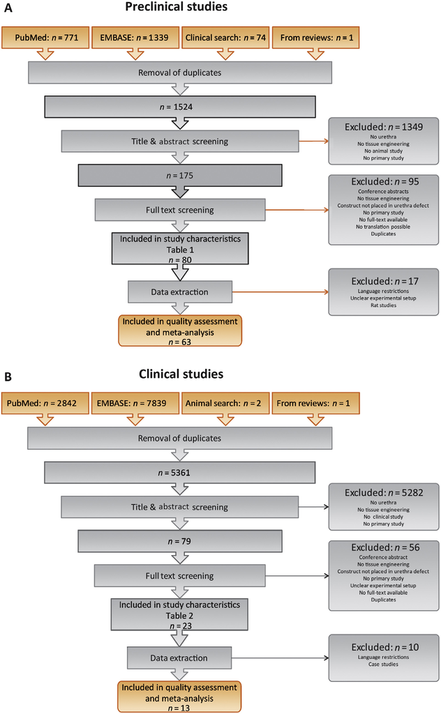

Fig. 1 – Flowchart of search and screening process of (A) preclinical studies and (B) clinical studies. The search was updated until June 1, 2016.

mesothelial cells (1/34). Stem cells, mostly derived from

adipose tissue, bone marrow or human umbilical cord, were

used in 10 studies.

3.2.2.

Clinical studies

Study characteristics of clinical studies are listed in Table 2

(see Supplementary data 4 for references of listed studies).

Clinical studies were performed with males, except for one

study (Table 2). From 23 studies, 16 used an inlay approach,

two a full circumferential procedure, one used both

approaches, while in four studies the procedure was

unclear. The majority of studies (21/23) used decellularized

bladder smooth muscle cells and/or urothelial cells.

3.3.

Quality assessment

The quality of reporting was assessed for 63 preclinical and

13

clinical

studies

from

which

outcome

data

could

sufficiently be extracted for inclusion in the meta-analysis

(Fig. 2). Results per study are listed in Supplementary data

5. Reporting of information regarding included animals/

patients, such as species and strain, sex, number of animals/

patients, age/weight, and patient inclusion criteria, were

generally well described.

Overall quality of the experimental setup was poor.

Although the different experimental groups were well

described, hardly any control groups were present, and

randomization and blinding were seldom mentioned in

both preclinical and clinical studies. Also, clinical study

protocols were not published. However, surgical procedure,

composition, size, and preparation of the implants were

clearly described in most studies. Reporting of outcome

measures was good for both preclinical and clinical studies

with respect to the description of outcome measures,

follow-up time, and side effects. The number of drop-outs

was clearly mentioned in clinical studies, but only in half of

the preclinical studies. For preclinical studies, histological

sampling location and representativeness of the results

were poorly described.

3.4.

Meta-analysis

3.4.1.

Preclinical studies

For full circumferential repair (Fig. 3A), the addition of cells

significantly

reduced

the

probability

of

side

effects,

independent of the type of biomaterial used (p = 0.001).

Exact point estimates including CI are given in Supplemen-

tary data 6. Regarding the type of biomaterial, when no cells

were used, estimates show that synthetic materials had a

higher probability for having no side effects compared to

decellularized and natural materials. With cells seeded,

estimated probabilities were similar for all materials. For

functionality and study completion, estimated probabilities

were similar for all study conditions.

For inlay repair (Fig. 3B), the addition of cells signifi-

cantly reduced the probability of side effects (p = 0.003),

albeit less than for full repair. Estimated probabilities were

similar for all types of biomaterial regardless of the addition

of cells. For functionality and study completion, estimated

probabilities were similar for all study conditions. It was

impossible to estimate study completion probability per

biomaterial as almost all animals survived inlay repair

(statistical model did not converge).

Although estimated probabilities for dogs and rabbits

were slightly different, differences were not statistically

significant. Consequently, the animal species had only

marginal influence on outcome (data not shown).

3.4.2.

Clinical studies

For clinical studies, a similar meta-analysis was performed

(Fig. 3C). Only inlay repair using decellularized materials

with or without cells could be analyzed due to the limited

number of other combinations. No statistically significant

differences were found for the inclusion of cells for any of

the outcome measures (p = 0.5 for side effects, p = 0.7 for

functionality, and p = 0.08 for study completion).

When comparing preclinical and clinical estimated

probabilities, point estimates for absence of side effects

after inlay repair seem to be higher in clinical studies for

both acellular and cellular templates. For functionality, the

point estimates were similar. The estimated probability for

study completion was much lower in clinical studies

compared to preclinical studies regardless of the addition

of cells, but these cannot be directly compared due to

distinctive definitions for study completion and differences

in disease status.

4.

Discussion

Reconstructive surgery using biomaterials has been studied

as an alternative approach for urethral repair since the early

seventies and efforts along these lines expanded rapidly in

the nineties when the term ‘‘Tissue Engineering’’ was

introduced (Fig. 4) [11]. Nowadays, preclinical studies have

been readily performed, but clinical studies have not

followed this trend. Although many (pre)clinical studies

have been performed, tissue engineering is not used as an

alternative treatment in routine clinical practice, except for

a select patient group with a history of failed repairs [22–

24]. In this systematic review, all (pre)clinical publications

on urethra tissue engineering until June 2016 were ana-

lyzed to assess the evidence for the efficacy. For clinical

studies, the term ‘‘effectiveness’’ may be more suitable, as

most studies included in this review showed a heteroge-

neous patient population [25]. However, we used the term

‘‘efficacy’’ for preclinical and clinical studies throughout this

systematic review. For both preclinical and clinical studies,

tissue engineering had a high probability for functionality,

defined as voiding with continence. Study completion was

high in preclinical studies, but not in clinical studies. This

may be related to the difference in our definition of study

completion and in study design. In preclinical studies,

animals generally only need to survive for several months to

study the tissue regeneration process, compared with

patients that need to show a good long term outcome

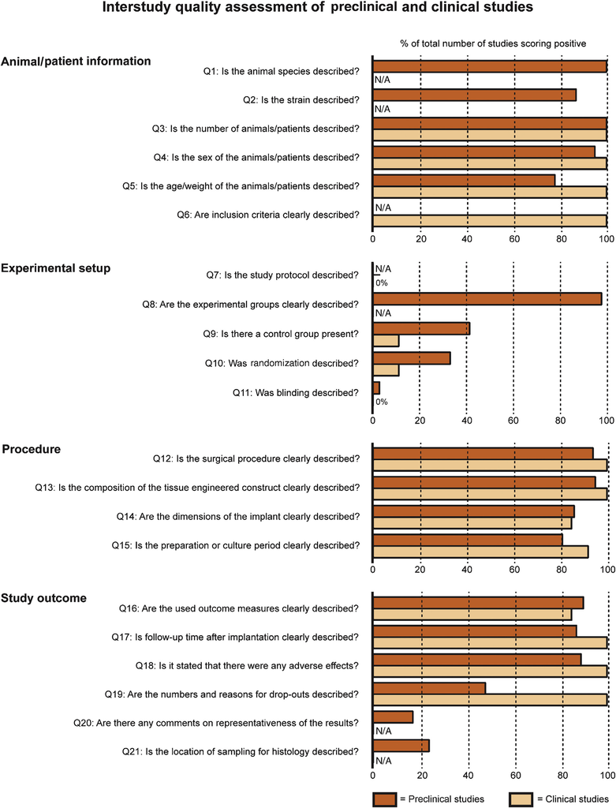

Fig. 2 – Quality assessment of preclinical and clinical studies. All studies included for meta-analysis were scored on clear reporting of several key

parameters (Q1–Q21) showing that study design such as inclusion of proper control groups, associated randomization and blinding, reporting of key

parameters such as representativeness of shown results, and drop-outs needs to be improved in preclinical studies.

N/A = not applicable; Q = question.

without reintervention and without being lost in follow-up.

Most

patients

had

a

history

of

failed

repairs

using

conventional techniques, while healthy animals were used.

As randomized clinical studies were lacking, for example,

comparison with standard treatments (free skin graft or

buccal mucosa urethroplasty) [3], no direct comparisons

with current clinical practice could be made. Available

literature about complex two-stage urethroplasty shows

complication-free rates, functionality, and study comple-

tion of approximately 62%, 67%, and 36% [26], similar to the

outcome of tissue engineered urethras (based on point

estimates). This suggests that tissue engineered urethras

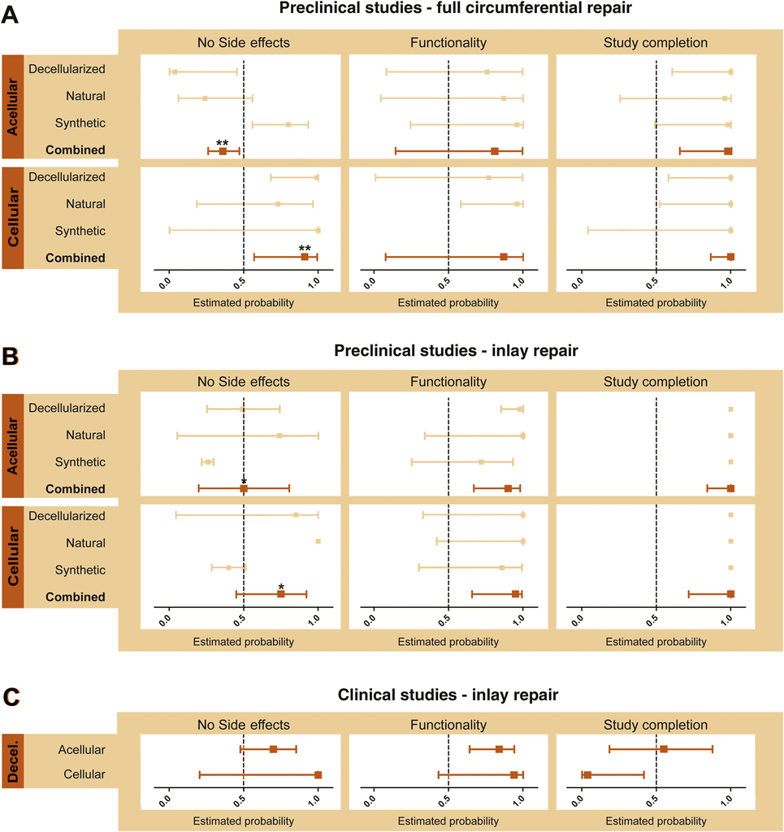

Fig. 3 – Estimated probability including 95% confidence intervals for the absence of side effects, functionality and study completion for (A) full

circumferential repair and (B) inlay repair in preclinical studies, both categorized for the use of cells and the type of biomaterial. (C) For the clinical

studies, only decellularized material with or without cells could be analyzed. The effect of cells on the three outcome measures was calculated in

estimated probabilities. Overall differences for cellular versus acellular templates were determined for each outcome measure for both full and inlay

repair. Specific point estimates and confidence interval are given in Supplementary data 6.

Decel. = decellularized.

* p = 0.003.

** p = 0.001.

may perform adequately and may be a valid alternative.

Clearly, randomized controlled clinical trials are needed to

clarify this issue.

4.1.

Application of cells

There is no consensus on the potential beneficial effects of

cell

seeding

of

tissue

engineered

constructs

for

the

urogenital system. For tissue engineering of the bladder,

the addition of cells did not give an overall beneficial effect

on tissue regeneration [27], while others claim that cells are

required for urethra repair of constructs >0.5 cm [28]. For

urethra tissue engineering, the inclusion of cells signifi-

cantly reduced side effects in preclinical studies for both full

(p = 0.001) and inlay (p = 0.003) defects. In other, less

comprehensive systematic reviews, a similar outcome

regarding the effectiveness of the addition of cells was

shown [29,30]. For full defects, cell addition has more added

value, which may be explained by the fact that cells can only

infiltrate from the two urethra edges, while in inlay repair

cell ingrowth can also occur from the sides, boosting cell

coverage.

The effects of cell addition on functionality and study

completion were not significant, regardless of surgical

procedure. This may be caused by the short follow-up

period underestimating long-term complications, such as

complete

strictures.

Meta-analysis

of

clinical

studies

showed no significant effect of cells for any of the outcome

measures. Consequently, the use of cells for the repair of

urethra in the clinic remains debatable.

4.2.

Type of biomaterial

Meta-analysis showed no differences in estimated proba-

bilities for the different materials in most of the conditions,

with the exception of synthetic materials showing better

estimated probabilities than natural materials in full

circumferential repair without cells regarding side effects.

For inlay repair in preclinical studies, synthetic materials

did not perform as well as in full repair, but only a limited

number of studies was reported.

Decellularized materials were used in the vast majority

of clinical studies. This may be related to the experience

with decellularized materials in other fields of tissue

engineering, such as skin tissue engineering [31]. Which

type of biomaterial is superior to the current state of the art

remains to be established.

4.3.

Selection of animal species

The choice of animal species is often based on financial

issues, experience of the researchers, ethical arguments and

practical restrictions [32–34]. An evidence-based approach

can aid in selection of the most appropriate model. In this

review, differences between treatment were not notably

influenced by the choice for rabbit or dog; however, a higher

statistical power would strengthen this claim.

4.4.

Clinical relevance and limitations of preclinical and clinical

studies

Quality of the experimental designs and reporting of

preclinical studies was generally low. Proper control groups,

such as sham operation groups and standard treatment

groups, were often lacking. Instead, the experimental

material without cells was generally considered the control.

In addition, outcome measures and drop-outs were not

specifically reported for each animal, complicating data

interpretation. Also, representativeness of presented data

was often not mentioned. This may have hampered clinical

translation of these preclinical findings. To improve this, all

design parameters and outcomes should be specifically

documented for individual animals similar to patients in

clinical studies. The ‘‘Gold standard publication checklist to

improve the quality of animal studies’’ by Hooijmans et al

[35] would be helpful for the design and reporting of

preclinical studies.

Another limitation for the level of evidence provided by

the preclinical studies is the use of healthy animals, in

which a created defect is immediately closed, compared to

patients with a history of stricture, lichen sclerosis or

hypospadias. From the patients in clinical studies 75% had

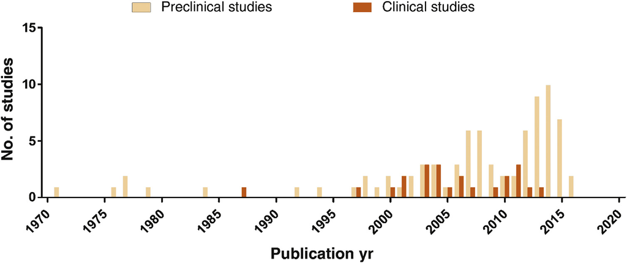

2012–2015.

one or more previous treatments, for example, dilation,

urethrotomy, or urethroplasty, before attempting the tissue

engineered constructs. The requirement of animal models

with injury or disease has been shown in other fields [36]

and should also be considered in tissue engineering, in this

particular situation by inducing strictures.

Clinical studies provided a low level of evidence due to

their setup, making the true effect of tissue engineering as

surrogate for the current standard treatment unclear. Only

El-Kassaby et al (Table 2) performed a small randomized

controlled study. To improve the level of evidence, more

randomized controlled studies are needed, preferably with

larger numbers of patients and longer follow-up. Compared

with

the

preclinical

studies,

reporting

of

important

parameters was much better, notably regarding drop-outs

and adverse events. Nevertheless, to further improve the

quality of the clinical studies, the study protocol should be

published with the manuscript and a detailed description of

patient inclusion criteria (eg, sex, age, and medical history)

should be provided.

The level of evidence is further limited by original

research’s susceptibility to publication bias [37], which may

lead to overestimation of the treatment effect in preclinical

studies. Recognition of this bias may partly explain the poor

translation of tissue engineering techniques to the clinic.

Furthermore, preclinical studies should better support

the clinical need: the majority of preclinical studies involves

full circumferential repair, where clinicians mainly perform

inlay repair [3]. This may be explained by preclinical

researchers attempting to prove the effectiveness of the

experimental treatment for the most problematic (circum-

ferential) procedures, assuming that it will also be effective

in less complicated (inlay) approaches.

Finally, inclusion of cells remains challenging in a

clinical setting as no beneficial effect was seen (in

11 patients), even though this significantly improved

preclinical outcome. It is possible that inclusion of cells

was perceived as too problematic, despite better results in a

preclinical setting and that in the final assessment the

choice was driven by parameters other than preclinical

outcome. To consider cells for clinical applications, its

efficacy has to be proven as the use of cells involves

extensive regulatory requirements which may hamper

clinical application [38–40]. In addition, the costs of

cellular implants will be higher compared with off-the-

shelf acellular implants, since two procedures are needed

(cell harvesting in urine or biopsy, and urethroplasty) and

in vitro cell expansion may be needed [41,42].

5.

Conclusions

The efficacy of tissue engineering for urethra repair could

not be determined due to a lack of controlled (pre)clinical

studies. However, meta-analysis outcomes (side effects,

functionality, and study completion) were comparable to

current treatment options described in literature, indicating

the potential of tissue engineering for urethra repair. The

findings of this systematic review may result in improved

study design which may aid the translation of tissue

engineered urethras to the clinic as an alternative for

autografts.

Author contributions: Willeke F. Daamen had full access to all the data in

the study and takes responsibility for the integrity of the data and the

accuracy of the data analysis.

Study concept and design: Versteegden, de Jonge, van Kuppevelt,

Oosterwijk, Feitz, de Vries, Daamen.

Acquisition of data: Versteegden, de Jonge.

Analysis and interpretation of data: Versteegden, de Jonge, IntHout, de

Vries, Daamen.

Drafting of the manuscript: Versteegden, de Jonge.

Critical revision of the manuscript for important intellectual content:

IntHout, van Kuppevelt, Oosterwijk, Feitz, de Vries, Daamen.

Statistical analysis: IntHout.

Obtaining funding: van Kuppevelt, Oosterwijk, Feitz, Daamen.

Administrative, technical, or material support: None.

Supervision: van Kuppevelt, Oosterwijk, Feitz, de Vries, Daamen.

Other: None.

Financial disclosures: Willeke F. Daamen certiﬁes that all conﬂicts of

interest, including speciﬁc ﬁnancial interests and relationships and

afﬁliations relevant to the subject matter or materials discussed in the

manuscript (eg, employment/afﬁliation, grants or funding, consultan-

cies, honoraria, stock ownership or options, expert testimony, royalties,

or patents ﬁled, received, or pending), are the following: None.

Funding/Support and role of the sponsor: PIDON (NovioTissue Project), a

combined subsidiary program of the Dutch Ministry of Economic Affairs,

and the states of Gelderland and Overijssel (PID101020).

Appendix A. Supplementary data

Supplementary data associated with this article can be

found, in the online version, at http://dx.doi.org/10.1016/j.

eururo.2017.03.026.

References

[1] Gallentine ML, Morey AF, Thompson Jr IM. Hypospadias: a contem-

porary epidemiologic assessment. Urology 2001;57:788–90.

[2] Pierik FH, Burdorf A, Nijman JM, et al. A high hypospadias rate in The

Netherlands. Hum Reprod (Oxford England) 2002;17:1112–5.

[3] Mundy AR. Management of urethral strictures. Postgrad Med J

2006;82:489–93.

[4] Brouwers MM, Feitz WF, Roelofs LA, et al. Risk factors for hypospa-

dias. Eur J Pediatr 2007;166:671–8.

[5] Santucci RA, Joyce GF, Wise M. Male urethral stricture disease. J Urol

2007;177:1667–74.

[6] Orabi H, Bouhout S, Morissette A, et al. Tissue engineering of urinary

bladder and urethra: advances from bench to patients. TSWJ

2013;2013:154564.

[7] Lumen N, Oosterlinck W, Hoebeke P. Urethral reconstruction using

buccal mucosa or penile skin grafts: systematic review and meta-

analysis. Urol Int 2012;89:387–94.

[8] Burger RA, Muller SC, el-Damanhoury H, et al. The buccal mucosal

graft for urethral reconstruction: a preliminary report. J Urol

1992;147:662–4.

[9] Barbagli G, Selli C, di Cello V, Mottola A. A one-stage dorsal free-

graft urethroplasty for bulbar

urethral strictures.

Br J Urol

1996;78:929–32.

[10] Dublin N, Stewart LH. Oral complications after buccal mucosal graft

harvest for urethroplasty. BJU Int 2004;94:867–9.

[11] Langer R, Vacanti JP. Tissue engineering. Science 1993;260:920–6.

[12] Place ES, Evans ND, Stevens MM. Complexity in biomaterials for

tissue engineering. Nat Mater 2009;8:457–70.

[13] Ma PX. Biomimetic materials for tissue engineering. Adv Drug Deliv

Rev 2008;60:184–98.

[14] Freed LE, Vunjak-Novakovic G, Biron RJ, et al. Biodegradable poly-

mer scaffolds for tissue engineering. Biotechnology NY 1994;12:

689–93.

[15] Guo S, Dipietro LA. Factors affecting wound healing. J Dental Res

2010;89:219–29.

[16] Bianco P, Robey PG. Stem cells in tissue engineering. Nature

2001;414:118–21.

[17] Sloff M, de Vries R, Geutjes P, et al. Tissue engineering in animal

models for urinary diversion: a systematic review. PLoS One

2014;9:e98734. http://dx.doi.org/10.1371/journal.pone.0105484.

[18] Hooijmans CR, Tillema A, Leenaars M, Ritskes-Hoitinga M. Enhanc-

ing search efﬁciency by means of a search ﬁlter for ﬁnding all

studies

on

animal

experimentation

in

PubMed.

Lab

Anim

2010;44:170–5.

[19] de Vries RB, Hooijmans CR, Tillema A, Leenaars M, Ritskes-Hoitinga

M. A search ﬁlter for increasing the retrieval of animal studies in

Embase. Lab Anim 2011;45:268–70.

[20] Akaike H. Akaike’s Information Criterion. In: Lovric M, editor.

International Encyclopedia of Statistical Science. Berlin, Heidel-

berg: Springer Berlin Heidelberg; 2011. p. 25.

[21] Zou GY. Assessment of risks by predicting counterfactuals. Stat Med

2009;28:3761–81.

[22] Barbagli G, Sansalone S, Djinovic R, Romano G, Lazzeri M. Current

controversies in reconstructive surgery of the anterior urethra: a

clinical overview. Int Braz J Urol 2012;38:307–16, discussion 16.

[23] Mundy AR, Andrich DE. Urethral strictures. BJU Int 2011;107:6–26.

[24] Subramaniam R, Spinoit AF, Hoebeke P. Hypospadias repair: an

overview of the actual techniques. Semin Plast Surg 2011;25:

206–12.

[25] Singal AG, Higgins PD, Waljee AK. A primer on effectiveness and

efﬁcacy trials. Clin Transl Gastroenterol 2014;5:e45. http://dx.doi.

org/10.1038/ctg.2013.13.

[26] Faure A, Bouty A, Nyo YL, O’Brien M, Heloury Y. Two-stage graft

urethroplasty for proximal and complicated hypospadias in chil-

dren: a retrospective study. J Pediatr Urol 2016;12:286.

[27] Sloff M, Simaioforidis V, de Vries R, Oosterwijk E, Feitz W. Tissue

engineering of the bladder–reality or myth?. A systematic review. J

Urol 2014;192:1035–42.

[28] Dorin RP, Pohl HG, De Filippo RE, Yoo JJ, Atala A. Tubularized

urethral replacement with unseeded matrices: what is the maxi-

mum distance for normal tissue regeneration? World J Urol

2008;26:323–6.

[29] Qi N, Li WJ, Tian H. A systematic review of animal and clinical

studies on the use of scaffolds for urethral repair. J Huazhong Univ

Sci Technol Med Sci 2016;36:111–7.

[30] Xue JD, Gao J, Fu Q, Feng C, Xie H. Seeding cell approach for tissue-

engineered urethral reconstruction in animal study: a systematic

review and meta-analysis. Exp Biol Med 2016;241:1416–28.

[31] Debels H, Hamdi M, Abberton K, Morrison W. Dermal matrices and

bioengineered skin substitutes: a critical review of current options.

Plast Reconstr Surg Glob Open 2015;3:e284. http://dx.doi.org/10.

1097/GOX.0000000000000219.

[32] de Vries RB, Buma P, Leenaars M, Ritskes-Hoitinga M, Gordijn B.

Reducing the number of laboratory animals used in tissue engi-

neering research by restricting the variety of animal models. Artic-

ular cartilage tissue engineering as a case study. Tissue Eng Part B

Rev 2012;18:427–35.

[33] de Vries RB, Wever KE, Avey MT, et al. The usefulness of systematic

reviews of animal experiments for the design of preclinical and

clinical studies. ILAR J 2014;55:427–37.

[34] Oerlemans AJ, Feitz WF, van Leeuwen E, Dekkers WJ. Regenerative

urology clinical trials: an ethical assessment of road blocks and

solutions. Tissue Engin Part B Rev 2013;19:41–7.

[35] Hooijmans CR, Leenaars M, Ritskes-Hoitinga M. A gold standard

publication checklist to improve the quality of animal studies, to

fully integrate the Three Rs, and to make systematic reviews more

feasible. Altern Lab Anim 2010;38:167–82.

[36] Dixit R, Boelsterli UA. Healthy animals and animal models of human

disease(s) in safety assessment of human pharmaceuticals, includ-

ing therapeutic antibodies. Drug Discov Today 2007;12:336–42.

[37] Korevaar DA, Hooft L, ter Riet G. Systematic reviews and meta-

analyses of preclinical studies: publication bias in laboratory ani-

mal experiments. Lab Anim 2011;45:225–30.

[38] Schneider CK, Salmikangas P, Jilma B, et al. Challenges with ad-

vanced therapy medicinal products and how to meet them. Nat Rev

Drug Discov 2010;9:195–201.

[39] EMA. Regulation (EC) No 1394/2007 of the European Parliament

and of the Council on advanced therapy medicinal products and

amending Directive 2001/83/EC and Regulation (EC) No 726/2004.

2007.

[40] Brevignon-Dodin L, Singh P. ATMP in practice: towards a new

industry landscape in tissue engineering. J Commerc Biotechnol

2009;15:59–65.

[41] Culme-Seymour EJ, Mason K, Vallejo-Torres L, et al. Cost of stem

cell-based tissue-engineered airway transplants in the United

Kingdom: case series. Tissue Eng Part A 2016;22:208–13.

[42] Zhang Y, McNeill E, Tian H, et al. Urine derived cells are a potential

source for urological tissue reconstruction. J Urol 2008;180:

2226–33.